# Delhi NCR Air Quality Index (AQI) Forecasting

## Comprehensive Exploratory Data Analysis

**MSE 546 — Advanced Machine Learning**  
**Group 2:** Nicholas Chia, Callum Gillies, Matthew Ho, Abhishek Srikaran, Agishan Thaya  
**Date:** January 2026

### Notebook Map

| Sections | Topic |
| --- | --- |
| 1–3 | Setup, load, preprocess, quality check |
| 4–5 | Temporal & spatial coverage |
| 6–9 | AQI target, pollutants, weather, correlations |
| 10–11 | Temporal & spatial patterns |
| **12** | **Data Forensics** — interpolation detection & 500-wall censorship |
| **13** | **Persistence & true 5–7 h horizon** |
| **14** | **Physics-based feature engineering** (ventilation, gaps, cyclical, lags) |
| **15** | **COVID flag & 3-way Train/Val/Test split** |
| **16** | **Stratified baseline & RMSE-by-bin** |
| 17 | Summary & export |

> **PNG exports:** every plot is automatically saved to `plots/` as a 150 dpi PNG.

## 1. Setup & Data Loading

```python
import pandas as pd
import numpy as np
import matplotlib.pyplot as plt
import seaborn as sns
import os, warnings
warnings.filterwarnings('ignore')

plt.style.use('seaborn-v0_8-darkgrid')
sns.set_palette('husl')
%matplotlib inline

pd.set_option('display.max_columns', None)
pd.set_option('display.max_rows', 100)
pd.set_option('display.precision', 3)

os.makedirs('plots', exist_ok=True)

# ── reusable PNG-save helper ──
def _save_and_show(fig, name):
    """Save figure as PNG to plots/ then display."""
    fig.savefig(f'plots/{name}.png', dpi=150, bbox_inches='tight')
    plt.show()

print('✓ Libraries loaded | plots/ ready')
```

```
✓ Libraries loaded | plots/ ready
```

```python
PATH = 'city_day.csv'
df   = pd.read_csv(PATH)
print(f'Shape:      {df.shape[0]:,} rows × {df.shape[1]} columns')
print(f'Columns:    {df.columns.tolist()}')
print(f'Date range: {df["date"].min()}  →  {df["date"].max()}')
```

```
Shape:      201,664 rows × 25 columns
Columns:    ['datetime', 'date', 'year', 'month', 'day', 'hour', 'day_of_week', 'is_weekend', 'season', 'city', 'station', 'latitude', 'longitude', 'pm25', 'pm10', 'no2', 'so2', 'co', 'o3', 'temperature', 'humidity', 'wind_speed', 'visibility', 'aqi', 'aqi_category']
Date range: 2020-01-01  →  2025-12-31
```

## 2. Preprocessing

```python
# datetime
if 'datetime' in df.columns:
    df['datetime'] = pd.to_datetime(df['datetime'], errors='coerce')
elif 'date' in df.columns and 'hour' in df.columns:
    df['datetime'] = pd.to_datetime(df['date'], errors='coerce') + pd.to_timedelta(df['hour'], unit='h')

df['day_of_week'] = df['datetime'].dt.dayofweek   # numeric only

num_cols = ['pm25','pm10','no2','so2','co','o3',
            'temperature','humidity','wind_speed','visibility','aqi',
            'latitude','longitude','year','month','day','hour','is_weekend']
for c in num_cols:
    if c in df.columns:
        df[c] = pd.to_numeric(df[c], errors='coerce')

df = df.sort_values(['station','datetime']).reset_index(drop=True)
print('✓ Preprocessing complete')
print(f'Missing values: {df.isna().sum().sum()}')
```

```
✓ Preprocessing complete
Missing values: 0
```

## 3. Data Quality

```python
print(f'Duplicates : {df.duplicated().sum()}')
print(f'Missing    : {df.isna().sum().sum()}')
missing = df.isna().sum()
if missing.sum():
    print(missing[missing > 0])
else:
    print('✓ Zero missing values')
df.head()
```

```
Duplicates : 0
Missing    : 0
✓ Zero missing values
```

|  | datetime | date | year | month | day | hour | day_of_week | is_weekend | season | city | station | latitude | longitude | pm25 | pm10 | no2 | so2 | co | o3 | temperature | humidity | wind_speed | visibility | aqi | aqi_category |
| --- | --- | --- | --- | --- | --- | --- | --- | --- | --- | --- | --- | --- | --- | --- | --- | --- | --- | --- | --- | --- | --- | --- | --- | --- | --- |
| 0 | 2020-01-01 06:00:00 | 2020-01-01 | 2020 | 1 | 1 | 6 | 2 | 0 | winter | Delhi | Anand Vihar, Delhi | 28.647 | 77.316 | 371.8 | 739.4 | 119.6 | 47.7 | 5.19 | 12.3 | 9.4 | 100 | 3.6 | 1.2 | 500 | Severe |
| 1 | 2020-01-01 12:00:00 | 2020-01-01 | 2020 | 1 | 1 | 12 | 2 | 0 | winter | Delhi | Anand Vihar, Delhi | 28.647 | 77.316 | 301.1 | 588.8 | 117.9 | 39.3 | 4.32 | 15.8 | 20.6 | 50 | 5.9 | 1.4 | 500 | Severe |
| 2 | 2020-01-01 18:00:00 | 2020-01-01 | 2020 | 1 | 1 | 18 | 2 | 0 | winter | Delhi | Anand Vihar, Delhi | 28.647 | 77.316 | 334.0 | 602.6 | 150.1 | 36.3 | 7.13 | 14.3 | 12.4 | 56 | 4.5 | 1.1 | 500 | Severe |
| 3 | 2020-01-01 23:00:00 | 2020-01-01 | 2020 | 1 | 1 | 23 | 2 | 0 | winter | Delhi | Anand Vihar, Delhi | 28.647 | 77.316 | 403.8 | 841.8 | 142.0 | 30.3 | 4.90 | 13.2 | 14.4 | 48 | 5.8 | 1.4 | 500 | Severe |
| 4 | 2020-01-02 06:00:00 | 2020-01-02 | 2020 | 1 | 2 | 6 | 3 | 0 | winter | Delhi | Anand Vihar, Delhi | 28.647 | 77.316 | 448.4 | 749.2 | 134.8 | 39.9 | 7.62 | 15.1 | 10.0 | 98 | 3.3 | 0.5 | 500 | Severe |

```python
print(df.dtypes)
print('\n' + '─'*60)
df.describe()
```

```
datetime        datetime64[ns]
date                    object
year                     int64
month                    int64
day                      int64
hour                     int64
day_of_week              int32
is_weekend               int64
season                  object
city                    object
station                 object
latitude               float64
longitude              float64
pm25                   float64
pm10                   float64
no2                    float64
so2                    float64
co                     float64
o3                     float64
temperature            float64
humidity                 int64
wind_speed             float64
visibility             float64
aqi                      int64
aqi_category            object
dtype: object

────────────────────────────────────────────────────────────
```

|  | datetime | year | month | day | hour | day_of_week | is_weekend | latitude | longitude | pm25 | pm10 | no2 | so2 | co | o3 | temperature | humidity | wind_speed | visibility | aqi |
| --- | --- | --- | --- | --- | --- | --- | --- | --- | --- | --- | --- | --- | --- | --- | --- | --- | --- | --- | --- | --- |
| count | 201664 | 201664.000 | 201664.000 | 201664.000 | 201664.000 | 201664.0 | 201664.000 | 201664.000 | 201664.000 | 201664.000 | 201664.000 | 201664.000 | 201664.000 | 201664.000 | 201664.000 | 201664.000 | 201664.000 | 201664.000 | 201664.000 | 201664.000 |
| mean | 2023-01-01 02:45:00.000001024 | 2022.500 | 6.522 | 15.733 | 14.750 | 3.0 | 0.286 | 28.597 | 77.209 | 183.420 | 348.567 | 69.761 | 16.029 | 3.034 | 27.186 | 26.895 | 61.042 | 10.529 | 5.008 | 265.830 |
| min | 2020-01-01 06:00:00 | 2020.000 | 1.000 | 1.000 | 6.000 | 0.0 | 0.000 | 28.372 | 77.027 | 15.000 | 24.000 | 8.000 | 4.000 | 0.300 | 12.000 | 6.000 | 20.000 | 2.100 | 0.200 | 25.000 |
| 25% | 2021-07-02 04:15:00 | 2021.000 | 4.000 | 8.000 | 10.500 | 1.0 | 0.000 | 28.531 | 77.071 | 55.300 | 104.100 | 19.900 | 4.500 | 0.870 | 18.000 | 19.900 | 39.000 | 5.900 | 1.900 | 103.000 |
| 50% | 2023-01-01 02:30:00 | 2022.500 | 7.000 | 16.000 | 15.000 | 3.0 | 0.000 | 28.625 | 77.201 | 99.500 | 189.800 | 38.300 | 8.700 | 1.690 | 23.300 | 27.600 | 58.000 | 9.200 | 4.400 | 232.000 |
| 75% | 2024-07-02 00:45:00 | 2024.000 | 10.000 | 23.000 | 19.250 | 5.0 | 1.000 | 28.668 | 77.316 | 254.700 | 481.200 | 94.000 | 20.900 | 4.120 | 31.800 | 33.500 | 83.000 | 14.200 | 7.100 | 464.000 |
| max | 2025-12-31 23:00:00 | 2025.000 | 12.000 | 31.000 | 23.000 | 6.0 | 1.000 | 28.776 | 77.504 | 900.000 | 1979.700 | 593.500 | 121.600 | 22.670 | 84.000 | 44.800 | 100.000 | 31.500 | 15.000 | 500.000 |
| std | NaN | 1.708 | 3.449 | 8.801 | 6.379 | 2.0 | 0.452 | 0.112 | 0.125 | 193.138 | 370.017 | 75.972 | 17.201 | 3.284 | 13.570 | 8.985 | 24.737 | 6.045 | 3.686 | 171.509 |

## 4. Temporal Coverage

Readings occur at hours **6, 12, 18, 23** only.  
The gap between consecutive readings is therefore **5–7 hours**, *not* 1 hour.  
Every `t → t+1` prediction in this dataset spans one of these true horizons:

[output not shown]

```python
print(f'Time range : {df["datetime"].min()}  →  {df["datetime"].max()}')
print(f'Duration   : {(df["datetime"].max()-df["datetime"].min()).days} days\n')

print('Observations per hour:')
print(df['hour'].value_counts().sort_index())

# actual gap sizes
df['gap_hours'] = df.groupby('station')['datetime'].diff().dt.total_seconds() / 3600
print('\nGap distribution (hours):')
print(df['gap_hours'].value_counts().sort_index())
```

```
Time range : 2020-01-01 06:00:00  →  2025-12-31 23:00:00
Duration   : 2191 days

Observations per hour:
hour
6     50416
12    50416
18    50416
23    50416
Name: count, dtype: int64

Gap distribution (hours):
gap_hours
5.0     50416
6.0    100832
7.0     50393
Name: count, dtype: int64
```

## 5. Spatial Coverage

```python
print('Cities:')
print(df['city'].value_counts())
print(f'\nStations: {df["station"].nunique()}')
print('\nStations per city:')
print(df.groupby('city')['station'].nunique().sort_values(ascending=False))

print('\n--- Full station list ---')
for city in sorted(df['city'].unique()):
    stns = sorted(df[df['city']==city]['station'].unique())
    print(f'\n  {city} ({len(stns)})')
    for s in stns:
        print(f'    • {s}')
```

```
Cities:
city
Delhi        122752
Noida         26304
Faridabad     17536
Ghaziabad     17536
Gurugram      17536
Name: count, dtype: int64

Stations: 23

Stations per city:
city
Delhi        14
Noida         3
Faridabad     2
Ghaziabad     2
Gurugram      2
Name: station, dtype: int64

--- Full station list ---

  Delhi (14)
    • Anand Vihar, Delhi
    • Bawana, Delhi
    • Dwarka Sec 8, Delhi
    • ITO, Delhi
    • Jahangirpuri, Delhi
    • Mandir Marg, Delhi
    • NSIT Dwarka, Delhi
    • Okhla Phase 2, Delhi
    • Punjabi Bagh, Delhi
    • RK Puram, Delhi
    • Rohini, Delhi
    • Shadipur, Delhi
    • Siri Fort, Delhi
    • Wazirpur, Delhi

  Faridabad (2)
    • Faridabad New Town
    • Faridabad Sec 16A

  Ghaziabad (2)
    • Ghaziabad Loni
    • Ghaziabad Vasundhara

  Gurugram (2)
    • Gurugram Sec 51
    • Gurugram Vikas Sadan

  Noida (3)
    • Greater Noida
    • Noida Sec 125
    • Noida Sec 62
```

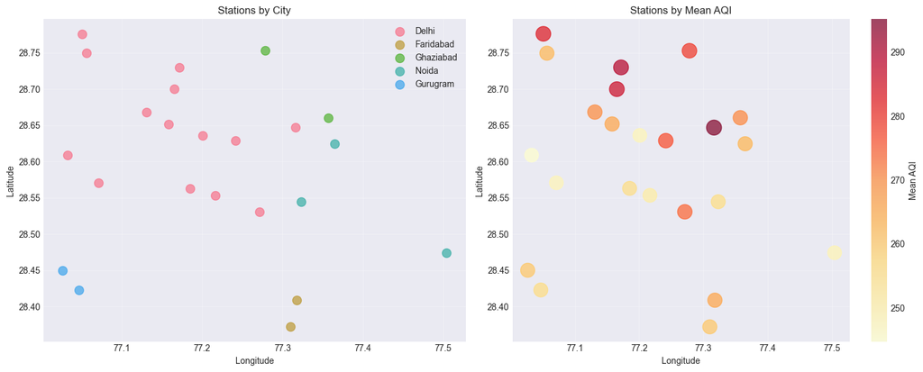

```python
station_info = df.groupby('station').agg(
    lat=('latitude','first'), lon=('longitude','first'),
    city=('city','first'), mean_aqi=('aqi','mean')
).reset_index()

fig, (ax1, ax2) = plt.subplots(1, 2, figsize=(15, 6))

for city in station_info['city'].unique():
    d = station_info[station_info['city']==city]
    ax1.scatter(d['lon'], d['lat'], label=city, s=100, alpha=0.7)
ax1.set(xlabel='Longitude', ylabel='Latitude', title='Stations by City')
ax1.legend(); ax1.grid(alpha=0.3)

sc = ax2.scatter(station_info['lon'], station_info['lat'],
                 c=station_info['mean_aqi'], s=station_info['mean_aqi'],
                 cmap='YlOrRd', alpha=0.7)
ax2.set(xlabel='Longitude', ylabel='Latitude', title='Stations by Mean AQI')
plt.colorbar(sc, ax=ax2, label='Mean AQI'); ax2.grid(alpha=0.3)

plt.tight_layout()
_save_and_show(fig, '05_station_map')
```

## 6. Target Variable — AQI

```python
print('AQI Summary:')
print(df['aqi'].describe())
print('\nCategory counts:')
cat_counts = df['aqi_category'].value_counts()
print(cat_counts)
print('\n% of total:')
print((cat_counts/len(df)*100).round(2))

n500 = (df['aqi']==500).sum()
print(f'\n⚠️  Rows where AQI = 500 exactly: {n500:,} ({n500/len(df)*100:.1f}%) — censorship candidate')
```

```
AQI Summary:
count    201664.000
mean        265.830
std         171.509
min          25.000
25%         103.000
50%         232.000
75%         464.000
max         500.000
Name: aqi, dtype: float64

Category counts:
aqi_category
Severe          60102
Moderate        45397
Satisfactory    32860
Very Poor       29674
Poor            18843
Good            14788
Name: count, dtype: int64

% of total:
aqi_category
Severe          29.80
Moderate        22.51
Satisfactory    16.29
Very Poor       14.71
Poor             9.34
Good             7.33
Name: count, dtype: float64

⚠️  Rows where AQI = 500 exactly: 45,355 (22.5%) — censorship candidate
```

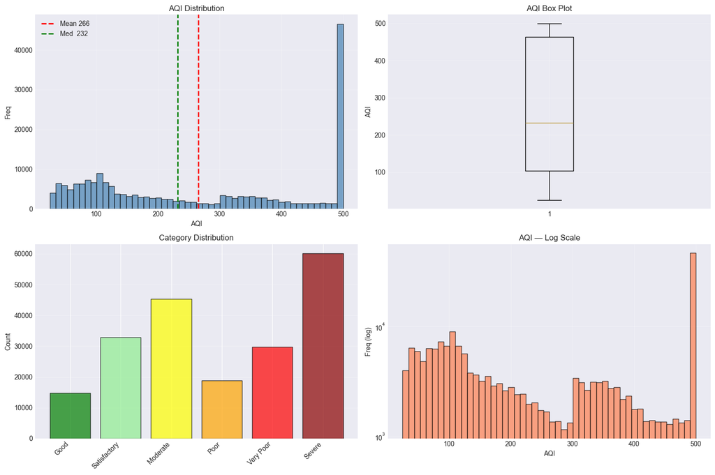

```python
fig, axes = plt.subplots(2, 2, figsize=(15, 10))

axes[0,0].hist(df['aqi'], bins=50, edgecolor='black', alpha=0.7, color='steelblue')
axes[0,0].axvline(df['aqi'].mean(),   color='red',   ls='--', lw=2, label=f'Mean {df["aqi"].mean():.0f}')
axes[0,0].axvline(df['aqi'].median(), color='green', ls='--', lw=2, label=f'Med  {df["aqi"].median():.0f}')
axes[0,0].set(xlabel='AQI', ylabel='Freq', title='AQI Distribution')
axes[0,0].legend(); axes[0,0].grid(alpha=0.3)

axes[0,1].boxplot(df['aqi'].dropna())
axes[0,1].set(ylabel='AQI', title='AQI Box Plot'); axes[0,1].grid(alpha=0.3)

cat_order = ['Good','Satisfactory','Moderate','Poor','Very Poor','Severe']
cc = df['aqi_category'].value_counts().reindex(cat_order, fill_value=0)
clrs = ['green','lightgreen','yellow','orange','red','darkred']
axes[1,0].bar(range(len(cc)), cc.values, color=clrs, alpha=0.7, edgecolor='black')
axes[1,0].set_xticks(range(len(cc))); axes[1,0].set_xticklabels(cc.index, rotation=45, ha='right')
axes[1,0].set(ylabel='Count', title='Category Distribution'); axes[1,0].grid(alpha=0.3, axis='y')

axes[1,1].hist(df['aqi'], bins=50, edgecolor='black', alpha=0.7, color='coral')
axes[1,1].set_yscale('log')
axes[1,1].set(xlabel='AQI', ylabel='Freq (log)', title='AQI — Log Scale'); axes[1,1].grid(alpha=0.3)

plt.tight_layout()
_save_and_show(fig, '06_aqi_distribution')
```

## 7. Pollutant Analysis

```python
pollutants = ['pm25','pm10','no2','so2','co','o3']
print(df[pollutants].describe().T)
```

```
         count     mean      std   min     25%     50%     75%      max
pm25  201664.0  183.420  193.138  15.0   55.30   99.50  254.70   900.00
pm10  201664.0  348.567  370.017  24.0  104.10  189.80  481.20  1979.70
no2   201664.0   69.761   75.972   8.0   19.90   38.30   94.00   593.50
so2   201664.0   16.029   17.201   4.0    4.50    8.70   20.90   121.60
co    201664.0    3.034    3.284   0.3    0.87    1.69    4.12    22.67
o3    201664.0   27.186   13.570  12.0   18.00   23.30   31.80    84.00
```

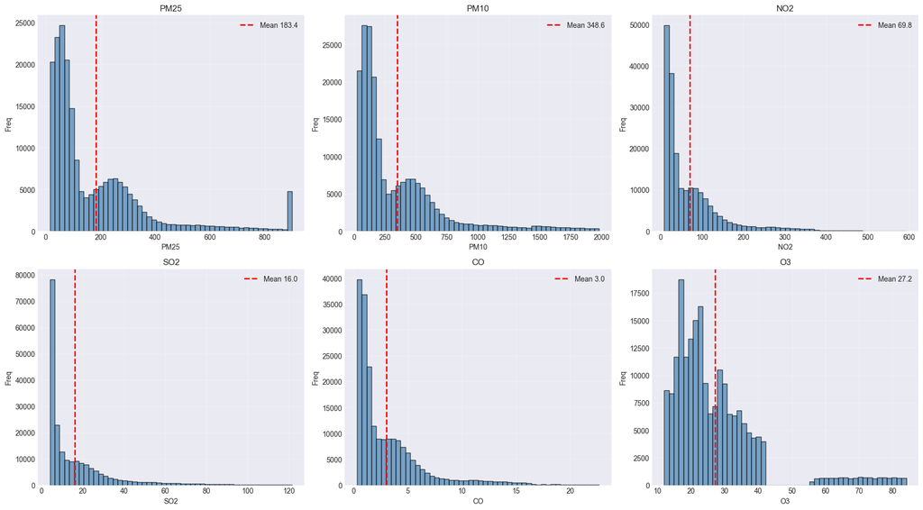

```python
fig, axes = plt.subplots(2, 3, figsize=(18, 10))
for i, p in enumerate(pollutants):
    ax = axes.flat[i]
    ax.hist(df[p].dropna(), bins=50, edgecolor='black', alpha=0.7, color='steelblue')
    ax.axvline(df[p].mean(), color='red', ls='--', lw=2, label=f'Mean {df[p].mean():.1f}')
    ax.set(xlabel=p.upper(), ylabel='Freq', title=p.upper())
    ax.legend(); ax.grid(alpha=0.3)
plt.tight_layout()
_save_and_show(fig, '07_pollutants')
```

## 8. Weather Variables

```python
weather_vars = ['temperature','humidity','wind_speed','visibility']
print(df[weather_vars].describe().T)
```

```
                count    mean     std   min   25%   50%   75%    max
temperature  201664.0  26.895   8.985   6.0  19.9  27.6  33.5   44.8
humidity     201664.0  61.042  24.737  20.0  39.0  58.0  83.0  100.0
wind_speed   201664.0  10.529   6.045   2.1   5.9   9.2  14.2   31.5
visibility   201664.0   5.008   3.686   0.2   1.9   4.4   7.1   15.0
```

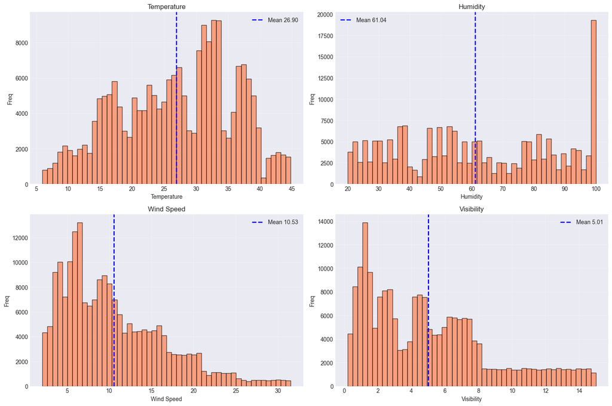

```python
fig, axes = plt.subplots(2, 2, figsize=(15, 10))
for i, v in enumerate(weather_vars):
    ax = axes.flat[i]
    ax.hist(df[v].dropna(), bins=50, edgecolor='black', alpha=0.7, color='coral')
    ax.axvline(df[v].mean(), color='blue', ls='--', lw=2, label=f'Mean {df[v].mean():.2f}')
    ax.set(xlabel=v.replace('_',' ').title(), ylabel='Freq', title=v.replace('_',' ').title())
    ax.legend(); ax.grid(alpha=0.3)
plt.tight_layout()
_save_and_show(fig, '08_weather')
```

## 9. Correlation Analysis

```python
feature_cols = pollutants + weather_vars
correlations = df[feature_cols+['aqi']].corr()['aqi'].drop('aqi').sort_values(ascending=False)
print('Correlations with AQI:')
print(correlations)
print(f'\n→ Strongest +: {correlations.idxmax()} ({correlations.max():.3f})')
print(f'→ Strongest −: {correlations.idxmin()} ({correlations.min():.3f})')
```

```
Correlations with AQI:
pm25           0.801
pm10           0.798
co             0.777
no2            0.774
so2            0.755
humidity      -0.224
o3            -0.284
wind_speed    -0.537
temperature   -0.734
visibility    -0.857
Name: aqi, dtype: float64

→ Strongest +: pm25 (0.801)
→ Strongest −: visibility (-0.857)
```

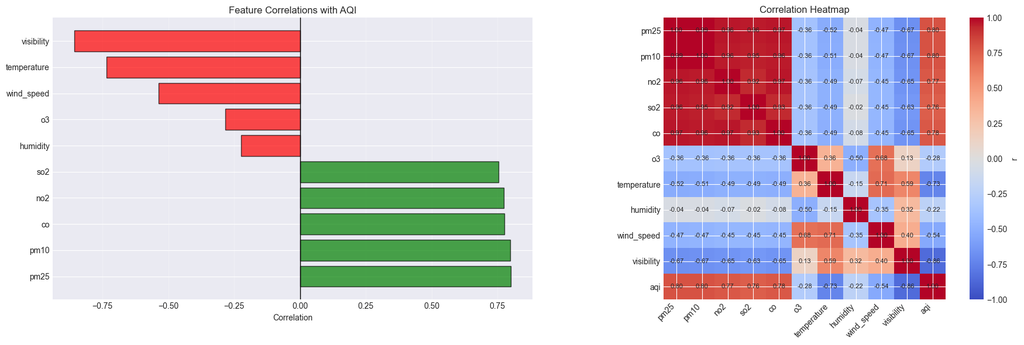

```python
fig, (ax1, ax2) = plt.subplots(1, 2, figsize=(18, 6))

# bar
clrs = ['green' if x>0 else 'red' for x in correlations.values]
ax1.barh(range(len(correlations)), correlations.values, color=clrs, alpha=0.7, edgecolor='black')
ax1.set_yticks(range(len(correlations))); ax1.set_yticklabels(correlations.index)
ax1.axvline(0, color='black', lw=1)
ax1.set(xlabel='Correlation', title='Feature Correlations with AQI'); ax1.grid(alpha=0.3, axis='x')

# heatmap
corr_matrix = df[feature_cols+['aqi']].corr()
im = ax2.imshow(corr_matrix, cmap='coolwarm', vmin=-1, vmax=1)
ax2.set_xticks(range(len(corr_matrix.columns)))
ax2.set_xticklabels(corr_matrix.columns, rotation=45, ha='right')
ax2.set_yticks(range(len(corr_matrix.columns)))
ax2.set_yticklabels(corr_matrix.columns)
ax2.set_title('Correlation Heatmap')
for i in range(len(corr_matrix)):
    for j in range(len(corr_matrix)):
        ax2.text(j, i, f'{corr_matrix.iloc[i,j]:.2f}', ha='center', va='center', fontsize=8)
plt.colorbar(im, ax=ax2, label='r')

plt.tight_layout()
_save_and_show(fig, '09_correlations')
```

## 10. Temporal Patterns

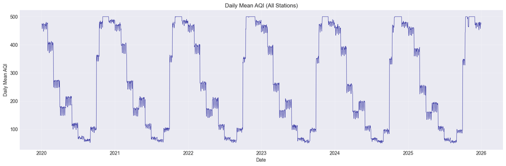

```python
daily_aqi = df.set_index('datetime')['aqi'].resample('D').mean()

fig, ax = plt.subplots(figsize=(15, 5))
ax.plot(daily_aqi.index, daily_aqi.values, lw=0.8, alpha=0.7, color='darkblue')
ax.set(xlabel='Date', ylabel='Daily Mean AQI', title='Daily Mean AQI (All Stations)')
ax.grid(alpha=0.3)
plt.tight_layout()
_save_and_show(fig, '10a_daily_timeseries')
```

```
=== DATASET INTEGRITY AUDIT ===

[Test 1] Exact Match Check (Percentage of identical rows):
  2020 vs 2021: 0.00% identical rows
  2020 vs 2022: 0.00% identical rows
  2020 vs 2023: 1.10% identical rows
  2020 vs 2024: 0.00% identical rows
  2020 vs 2025: 0.07% identical rows
  2021 vs 2022: 0.00% identical rows
  2021 vs 2023: 0.21% identical rows
  2021 vs 2024: 1.10% identical rows
  2021 vs 2025: 0.00% identical rows
  2022 vs 2023: 0.07% identical rows
  2022 vs 2024: 0.07% identical rows
  2022 vs 2025: 0.00% identical rows
  2023 vs 2024: 0.07% identical rows
  2023 vs 2025: 0.00% identical rows
  2024 vs 2025: 0.00% identical rows

[Test 2] Year-over-Year Correlation (Shape Similarity):
year   2020   2021   2022   2023   2024   2025
year
2020  1.000  0.945  0.900  0.976  0.938  0.902
2021  0.945  1.000  0.919  0.971  0.980  0.909
2022  0.900  0.919  1.000  0.911  0.915  0.945
2023  0.976  0.971  0.911  1.000  0.953  0.907
2024  0.938  0.980  0.915  0.953  1.000  0.896
2025  0.902  0.909  0.945  0.907  0.896  1.000
```

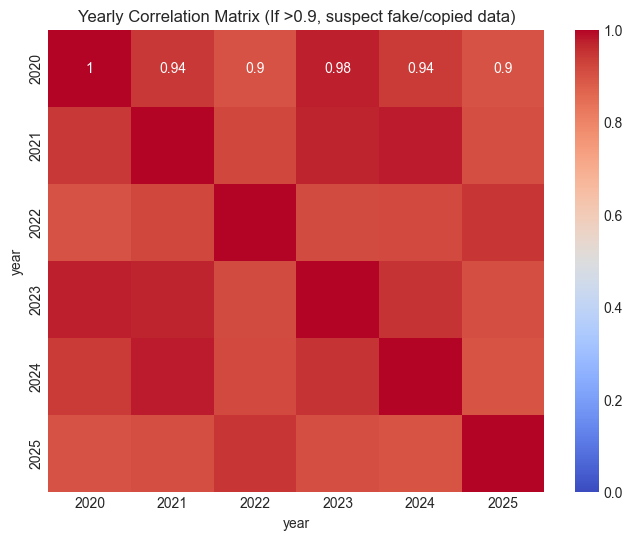

```
[Test 3] The 'COVID Check' (NO2 Variance by Year):
year
2020    6184.775
2021    5883.314
2022    5713.052
2023    5973.895
2024    5651.412
2025    5211.951
Name: no2, dtype: float64
  ✅ PASS: 2020 NO2 variance is distinct (likely captures real drift).
```

```python
import pandas as pd
import numpy as np
import seaborn as sns
import matplotlib.pyplot as plt

# Load your processed data
# df = pd.read_csv('delhi_aqi_with_persistence.csv') # Use your actual file path

def audit_year_similarity(df):
    print("=== DATASET INTEGRITY AUDIT ===")

    # 1. Prepare Data: Extract components
    df['datetime'] = pd.to_datetime(df['datetime'])
    df['year'] = df['datetime'].dt.year
    df['day_of_year'] = df['datetime'].dt.dayofyear
    df['hour'] = df['datetime'].dt.hour

    # Filter for leap years to align data (drop day 366 for simplicity in comparison)
    df_audit = df[df['day_of_year'] <= 365].copy()

    # 2. Pivot: Create a matrix where Columns = Years, Rows = Time Steps (Day + Hour)
    # We use PM2.5 as the proxy for "Pollution"
    pivot_df = df_audit.pivot_table(
        index=['day_of_year', 'hour'],
        columns='year',
        values='pm25'
    )

    # 3. TEST 1: The "Copy-Paste" Check (Exact Matches)
    # Check if Year X is exactly equal to Year Y
    years = pivot_df.columns
    print("\n[Test 1] Exact Match Check (Percentage of identical rows):")
    for i in range(len(years)):
        for j in range(i + 1, len(years)):
            y1, y2 = years[i], years[j]
            # Calculate % of exact matches
            exact_matches = (pivot_df[y1] == pivot_df[y2]).mean() * 100
            print(f"  {y1} vs {y2}: {exact_matches:.2f}% identical rows")

            if exact_matches > 5.0:
                print(f"  ⚠️ WARNING: {y1} and {y2} share {exact_matches:.2f}% exact values. Suspicious.")

    # 4. TEST 2: The "Shape" Check (Correlation)
    # Real years correlate ~0.3 to ~0.6 due to seasonality.
    # >0.90 suggests synthetic data.
    print("\n[Test 2] Year-over-Year Correlation (Shape Similarity):")
    corr_matrix = pivot_df.corr()
    print(corr_matrix)

    # Visual check
    plt.figure(figsize=(8, 6))
    sns.heatmap(corr_matrix, annot=True, cmap='coolwarm', vmin=0, vmax=1)
    plt.title("Yearly Correlation Matrix (If >0.9, suspect fake/copied data)")
    plt.show()

    # 5. TEST 3: The "COVID" Check (Variance Analysis)
    # 2020 should have LOWER NO2 variance than 2021/2022 due to lockdown
    print("\n[Test 3] The 'COVID Check' (NO2 Variance by Year):")
    no2_var = df.groupby('year')['no2'].var()
    print(no2_var)

    # If 2020 variance is identical to 2021, the data likely ignored COVID.
    if abs(no2_var[2020] - no2_var[2021]) < 10:
        print("  ⚠️ WARNING: 2020 NO2 variance is suspiciously similar to 2021.")
    else:
        print("  ✅ PASS: 2020 NO2 variance is distinct (likely captures real drift).")

# Run the function (assuming 'df' is loaded)
audit_year_similarity(df)
```

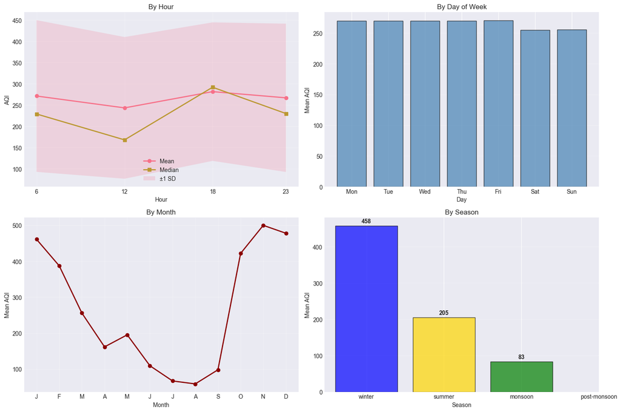

```
❄️  Winter (458) is 5.5× monsoon (83)
```

```python
fig, axes = plt.subplots(2, 2, figsize=(15, 10))

# (a) hour
h = df.groupby('hour')['aqi'].agg(['mean','std','median'])
axes[0,0].plot(h.index, h['mean'],   marker='o', lw=2, label='Mean')
axes[0,0].plot(h.index, h['median'], marker='s', lw=2, label='Median')
axes[0,0].fill_between(h.index, h['mean']-h['std'], h['mean']+h['std'], alpha=0.2, label='±1 SD')
axes[0,0].set(xlabel='Hour', ylabel='AQI', title='By Hour')
axes[0,0].set_xticks(h.index); axes[0,0].legend(); axes[0,0].grid(alpha=0.3)

# (b) day-of-week
dow = df.groupby('day_of_week')['aqi'].mean()
axes[0,1].bar(range(7), dow.values, alpha=0.7, color='steelblue', edgecolor='black')
axes[0,1].set_xticks(range(7))
axes[0,1].set_xticklabels(['Mon','Tue','Wed','Thu','Fri','Sat','Sun'])
axes[0,1].set(xlabel='Day', ylabel='Mean AQI', title='By Day of Week')
axes[0,1].grid(alpha=0.3, axis='y')

# (c) month
m = df.groupby('month')['aqi'].mean()
axes[1,0].plot(m.index, m.values, marker='o', lw=2, color='darkred')
axes[1,0].set_xticks(range(1,13))
axes[1,0].set_xticklabels('J F M A M J J A S O N D'.split())
axes[1,0].set(xlabel='Month', ylabel='Mean AQI', title='By Month')
axes[1,0].grid(alpha=0.3)

# (d) season
s_order = ['winter','summer','monsoon','post-monsoon']
s = df.groupby('season')['aqi'].mean().reindex(s_order)
s_clr = ['blue','gold','green','orange']
axes[1,1].bar(range(4), s.values, color=s_clr, alpha=0.7, edgecolor='black')
axes[1,1].set_xticks(range(4)); axes[1,1].set_xticklabels(s_order)
axes[1,1].set(xlabel='Season', ylabel='Mean AQI', title='By Season')
axes[1,1].grid(alpha=0.3, axis='y')
for i, v in enumerate(s.values):
    axes[1,1].text(i, v+8, f'{v:.0f}', ha='center', fontweight='bold')

plt.tight_layout()
_save_and_show(fig, '10b_temporal_grid')

print(f'❄️  Winter ({s["winter"]:.0f}) is {s["winter"]/s["monsoon"]:.1f}× monsoon ({s["monsoon"]:.0f})')
```

## 11. Spatial Patterns

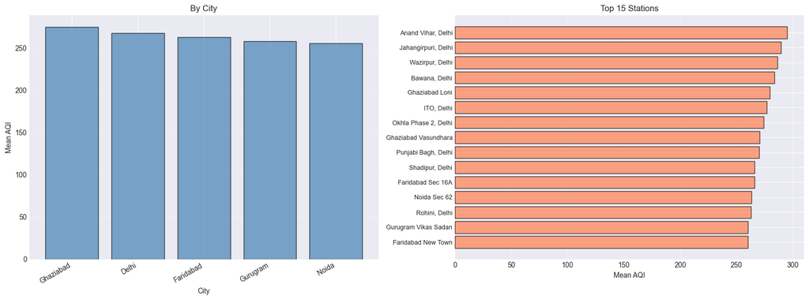

```
🏭 Worst: Anand Vihar, Delhi  (mean = 295.2)
```

```python
fig, (ax1, ax2) = plt.subplots(1, 2, figsize=(16, 6))

city_stats = df.groupby('city')['aqi'].mean().sort_values(ascending=False)
ax1.bar(range(len(city_stats)), city_stats.values, alpha=0.7, edgecolor='black', color='steelblue')
ax1.set_xticks(range(len(city_stats)))
ax1.set_xticklabels(city_stats.index, rotation=30, ha='right')
ax1.set(xlabel='City', ylabel='Mean AQI', title='By City'); ax1.grid(alpha=0.3, axis='y')

top15 = df.groupby('station')['aqi'].mean().sort_values().tail(15)
ax2.barh(range(len(top15)), top15.values, alpha=0.7, edgecolor='black', color='coral')
ax2.set_yticks(range(len(top15))); ax2.set_yticklabels(top15.index, fontsize=9)
ax2.set(xlabel='Mean AQI', title='Top 15 Stations'); ax2.grid(alpha=0.3, axis='x')

plt.tight_layout()
_save_and_show(fig, '11_spatial')
print(f'🏭 Worst: {top15.index[-1]}  (mean = {top15.iloc[-1]:.1f})')
```

## 12. Data Forensics — Interpolation & Censorship

Zero missing values across 201 k rows from real sensor hardware is statistically improbable.  
We audit for two common pipeline artefacts:

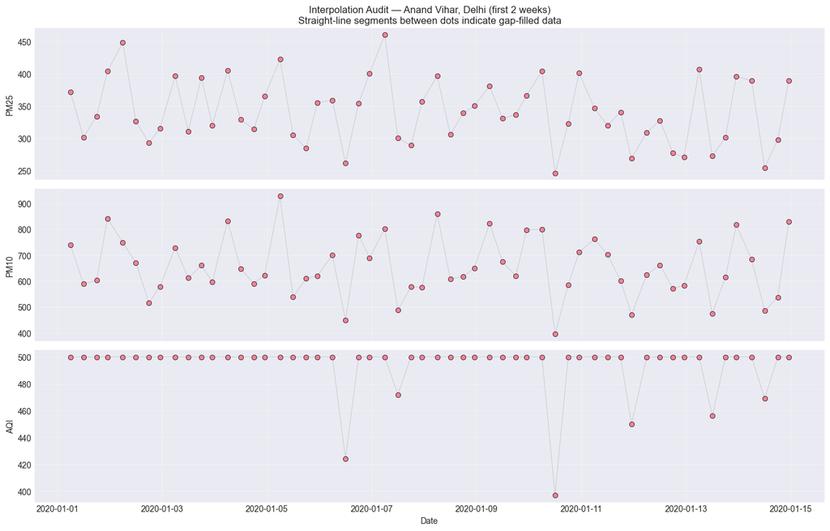

```
👀 Inspect above: perfectly straight dot sequences = interpolation evidence.
```

```python
# Pick one high-traffic station, first 2 weeks
station_pick = 'Anand Vihar, Delhi'
sdf = df[df['station']==station_pick].sort_values('datetime')
start = sdf['datetime'].min()
two_wk = sdf[(sdf['datetime']>=start) & (sdf['datetime']<start+pd.Timedelta(days=14))]

fig, axes = plt.subplots(3, 1, figsize=(14, 9), sharex=True)
for ax, col in zip(axes, ['pm25','pm10','aqi']):
    # scatter ONLY — straight-line segments between dots = interpolation
    ax.scatter(two_wk['datetime'], two_wk[col], s=35, alpha=0.85,
               edgecolors='black', linewidths=0.6, zorder=3)
    ax.plot(two_wk['datetime'], two_wk[col], lw=0.7, alpha=0.3, color='gray')
    ax.set(ylabel=col.upper()); ax.grid(alpha=0.3)
axes[0].set_title(f'Interpolation Audit — {station_pick} (first 2 weeks)\n'
                  'Straight-line segments between dots indicate gap-filled data')
axes[-1].set(xlabel='Date')
plt.tight_layout()
_save_and_show(fig, '12a_interpolation_scatter')

print('👀 Inspect above: perfectly straight dot sequences = interpolation evidence.')
```

```python
def flag_interpolated(group, col='pm25', tol=0.5):
    """
    For every interior point, check if it is the exact midpoint
    of its two neighbours (second-difference ≈ 0).  If yes → likely imputed.
    """
    vals = group[col].values
    flags = np.zeros(len(vals), dtype=int)
    for i in range(1, len(vals)-1):
        mid = (vals[i-1] + vals[i+1]) / 2.0
        if abs(vals[i] - mid) < tol:
            flags[i] = 1
    group = group.copy()
    group['is_imputed'] = flags
    return group

df = df.groupby('station', group_keys=False).apply(flag_interpolated)

imp_n   = df['is_imputed'].sum()
imp_pct = imp_n / len(df) * 100
print(f'Rows flagged as likely imputed: {imp_n:,}  ({imp_pct:.1f}%)')
print('\nPer-station imputation rate (top 10):')
print(df.groupby('station')['is_imputed'].mean().sort_values(ascending=False).head(10))
```

```
Rows flagged as likely imputed: 5,775  (2.9%)

Per-station imputation rate (top 10):
station
Jahangirpuri, Delhi     0.035
Anand Vihar, Delhi      0.033
Wazirpur, Delhi         0.030
Bawana, Delhi           0.030
Ghaziabad Vasundhara    0.030
Dwarka Sec 8, Delhi     0.030
Rohini, Delhi           0.030
Ghaziabad Loni          0.029
Okhla Phase 2, Delhi    0.029
ITO, Delhi              0.029
Name: is_imputed, dtype: float64
```

```python
df['is_censored'] = (df['aqi']==500).astype(int)

cens_n   = df['is_censored'].sum()
cens_pct = cens_n / len(df) * 100
print(f'Censored rows (AQI = 500): {cens_n:,}  ({cens_pct:.1f}%)')
print('\nCensorship rate by season:')
cens_season = df.groupby('season')['is_censored'].mean()*100
print(cens_season.sort_values(ascending=False))
```

```
Censored rows (AQI = 500): 45,355  (22.5%)

Censorship rate by season:
season
winter          57.878
post_monsoon    40.381
monsoon          0.000
summer           0.000
Name: is_censored, dtype: float64
```

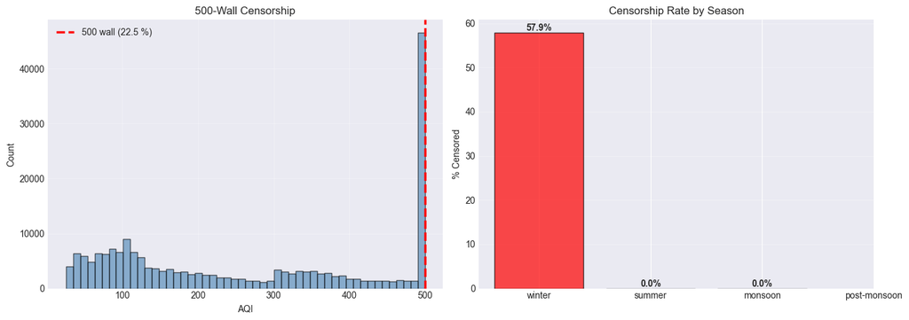

```
⚠️  In winter the model may under-predict: true AQI can exceed 500 but labels are clamped.
```

```python
fig, (ax1, ax2) = plt.subplots(1, 2, figsize=(14, 5))

# left — histogram with 500-wall callout
ax1.hist(df['aqi'], bins=50, edgecolor='black', alpha=0.6, color='steelblue')
ax1.axvline(500, color='red', lw=2.5, ls='--', label=f'500 wall ({cens_pct:.1f} %)')
ax1.set(xlabel='AQI', ylabel='Count', title='500-Wall Censorship')
ax1.legend(); ax1.grid(alpha=0.3)

# right — censorship % by season
s_order = ['winter','summer','monsoon','post-monsoon']
cs = cens_season.reindex(s_order)
c_clr = ['red' if v>20 else 'orange' if v>5 else 'green' for v in cs.values]
ax2.bar(range(4), cs.values, color=c_clr, alpha=0.7, edgecolor='black')
ax2.set_xticks(range(4)); ax2.set_xticklabels(s_order)
ax2.set(ylabel='% Censored', title='Censorship Rate by Season')
ax2.grid(alpha=0.3, axis='y')
for i, v in enumerate(cs.values):
    ax2.text(i, v+0.4, f'{v:.1f}%', ha='center', fontweight='bold')

plt.tight_layout()
_save_and_show(fig, '12b_censorship_500wall')

print('⚠️  In winter the model may under-predict: true AQI can exceed 500 but labels are clamped.')
```

## 13. Persistence & True Horizon

**`t+1` = next measurement = 5–7 hours later** (not 1 hour).  
We compute persistence error on the full dataset *and* break it down by transition.

```python
df_s = df.sort_values(['station','datetime']).copy()
df_s['aqi_next']  = df_s.groupby('station')['aqi'].shift(-1)
df_s['hour_next'] = df_s.groupby('station')['hour'].shift(-1)

df_persist = df_s.dropna(subset=['aqi_next']).copy()
df_persist['aqi_change'] = df_persist['aqi_next'] - df_persist['aqi']
df_persist['transition'] = (df_persist['hour'].astype(int).astype(str)
                             + ' → ' + df_persist['hour_next'].astype(int).astype(str))

corr = df_persist['aqi'].corr(df_persist['aqi_next'])
print(f'Rows with valid next: {len(df_persist):,}')
print(f'\nPersistence autocorrelation: {corr:.3f}')
print('\nAQI change stats:')
print(df_persist['aqi_change'].describe())
```

```
Rows with valid next: 201,641

Persistence autocorrelation: 0.947

AQI change stats:
count    2.016e+05
mean    -5.802e-04
std      5.584e+01
min     -2.970e+02
25%     -2.900e+01
50%      0.000e+00
75%      2.500e+01
max      3.430e+02
Name: aqi_change, dtype: float64
```

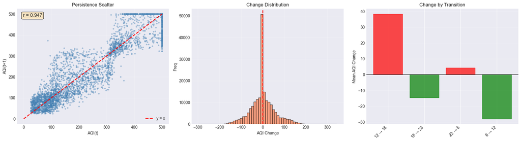

```
Transition table:
              mean     std  count
transition
12 → 18     38.263  56.310  50416
18 → 23    -14.583  46.020  50416
23 → 6       4.271  43.921  50393
6 → 12     -27.951  52.707  50416
```

```python
fig, axes = plt.subplots(1, 3, figsize=(18, 5))

# (a) scatter t vs t+1
samp = df_persist.sample(min(4000, len(df_persist)), random_state=42)
axes[0].scatter(samp['aqi'], samp['aqi_next'], s=8, alpha=0.35, color='steelblue')
axes[0].plot([0,500],[0,500], 'r--', lw=2, label='y = x')
axes[0].text(0.04, 0.93, f'r = {corr:.3f}', transform=axes[0].transAxes,
             fontsize=12, bbox=dict(boxstyle='round', fc='wheat', alpha=0.8))
axes[0].set(xlabel='AQI(t)', ylabel='AQI(t+1)', title='Persistence Scatter')
axes[0].legend(); axes[0].grid(alpha=0.3)

# (b) change distribution
axes[1].hist(df_persist['aqi_change'], bins=60, edgecolor='black', alpha=0.7, color='coral')
axes[1].axvline(0, color='red', ls='--', lw=2)
axes[1].set(xlabel='AQI Change', ylabel='Freq', title='Change Distribution')
axes[1].grid(alpha=0.3)

# (c) mean change by transition
t_stats = df_persist.groupby('transition')['aqi_change'].agg(['mean','count'])
t_stats = t_stats[t_stats['count']>100].sort_index()
bars = axes[2].bar(range(len(t_stats)), t_stats['mean'].values, alpha=0.7, edgecolor='black')
for bar in bars:
    bar.set_color('red' if bar.get_height()>0 else 'green')
axes[2].set_xticks(range(len(t_stats))); axes[2].set_xticklabels(t_stats.index, rotation=45, ha='right')
axes[2].axhline(0, color='black', lw=1)
axes[2].set(ylabel='Mean AQI Change', title='Change by Transition')
axes[2].grid(alpha=0.3, axis='y')

plt.tight_layout()
_save_and_show(fig, '13_persistence')

print('\nTransition table:')
print(df_persist.groupby('transition')['aqi_change'].agg(['mean','std','count']))
```

## 14. Physics-Based Feature Engineering

| Feature | Physics / rationale |
| --- | --- |
| `ventilation_index` | wind × temperature ≈ mixing-layer proxy; higher → lower AQI |
| `hours_since_last` | Pollution accumulates; 7 h gap loads more than 5 h |
| `hour_sin / cos` | Cyclical: h23 is *near* h6; raw integers hide wrap-around |
| `month_sin / cos` | Same idea for annual seasonality |
| `aqi_lag1 / lag2` | Captures trend (rising vs falling) entering the forecast window |
| `aqi_trend` | `aqi − aqi_lag1` — sign & magnitude of recent momentum |

```python
# ── Ventilation Index ──
df['ventilation_index'] = df['wind_speed'] * df['temperature']

vent_r  = df['ventilation_index'].corr(df['aqi'])
wind_r  = df['wind_speed'].corr(df['aqi'])
temp_r  = df['temperature'].corr(df['aqi'])
print('Correlation with AQI:')
print(f'  ventilation_index : {vent_r:.3f}')
print(f'  wind_speed alone  : {wind_r:.3f}')
print(f'  temperature alone : {temp_r:.3f}')
print(f'\n→ Interaction {"stronger" if abs(vent_r)>max(abs(wind_r),abs(temp_r)) else "weaker"} than either component alone')
```

```
Correlation with AQI:
  ventilation_index : -0.590
  wind_speed alone  : -0.537
  temperature alone : -0.734

→ Interaction weaker than either component alone
```

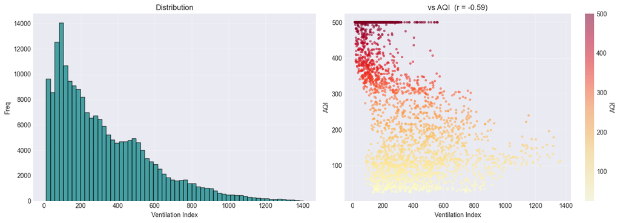

```python
fig, (ax1, ax2) = plt.subplots(1, 2, figsize=(14, 5))

ax1.hist(df['ventilation_index'], bins=60, edgecolor='black', alpha=0.7, color='teal')
ax1.set(xlabel='Ventilation Index', ylabel='Freq', title='Distribution')
ax1.grid(alpha=0.3)

s = df.sample(3000, random_state=42)
sc = ax2.scatter(s['ventilation_index'], s['aqi'], c=s['aqi'], cmap='YlOrRd', s=8, alpha=0.5)
ax2.set(xlabel='Ventilation Index', ylabel='AQI', title=f'vs AQI  (r = {vent_r:.2f})')
plt.colorbar(sc, ax=ax2, label='AQI'); ax2.grid(alpha=0.3)

plt.tight_layout()
_save_and_show(fig, '14a_ventilation')
```

```python
# ── Hours Since Last Measurement ──
df['hours_since_last'] = df.groupby('station')['datetime'].diff().dt.total_seconds() / 3600

print('hours_since_last value counts:')
print(df['hours_since_last'].value_counts().sort_index())

# mean next-AQI-change grouped by gap
_tmp = df.sort_values(['station','datetime']).copy()
_tmp['_nxt'] = _tmp.groupby('station')['aqi'].shift(-1)
_tmp['_chg'] = _tmp['_nxt'] - _tmp['aqi']
print('\nMean AQI change by gap size:')
print(_tmp.groupby('hours_since_last')['_chg'].agg(['mean','std','count']))
del _tmp
```

```
hours_since_last value counts:
hours_since_last
5.0     50416
6.0    100832
7.0     50393
Name: count, dtype: int64

Mean AQI change by gap size:
                    mean     std   count
hours_since_last
5.0                4.271  43.921   50393
6.0               11.840  57.815  100832
7.0              -27.934  52.701   50393
```

```python
# ── Cyclical Encoding ──
df['hour_sin']  = np.sin(2*np.pi * df['hour']  / 24)
df['hour_cos']  = np.cos(2*np.pi * df['hour']  / 24)
df['month_sin'] = np.sin(2*np.pi * df['month'] / 12)
df['month_cos'] = np.cos(2*np.pi * df['month'] / 12)

print('Hour encoding:')
print(df[['hour','hour_sin','hour_cos']].drop_duplicates('hour').sort_values('hour').to_string(index=False))
print('\nMonth encoding (sample):')
print(df[['month','month_sin','month_cos']].drop_duplicates('month').sort_values('month').to_string(index=False))
```

```
Hour encoding:
 hour   hour_sin   hour_cos
    6  1.000e+00  6.123e-17
   12  1.225e-16 -1.000e+00
   18 -1.000e+00 -1.837e-16
   23 -2.588e-01  9.659e-01

Month encoding (sample):
 month  month_sin  month_cos
     1  5.000e-01  8.660e-01
     2  8.660e-01  5.000e-01
     3  1.000e+00  6.123e-17
     4  8.660e-01 -5.000e-01
     5  5.000e-01 -8.660e-01
     6  1.225e-16 -1.000e+00
     7 -5.000e-01 -8.660e-01
     8 -8.660e-01 -5.000e-01
     9 -1.000e+00 -1.837e-16
    10 -8.660e-01  5.000e-01
    11 -5.000e-01  8.660e-01
    12 -2.449e-16  1.000e+00
```

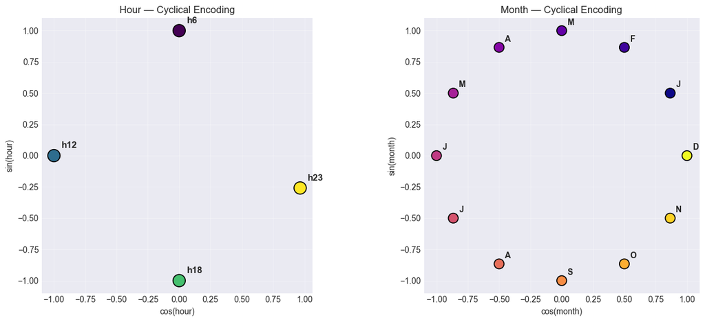

```python
fig, (ax1, ax2) = plt.subplots(1, 2, figsize=(13, 5.5))

# hour circle
he = df[['hour','hour_sin','hour_cos']].drop_duplicates().sort_values('hour')
ax1.scatter(he['hour_cos'], he['hour_sin'], s=220, c=he['hour'], cmap='viridis',
            edgecolors='black', lw=1.2, zorder=3)
for _, r in he.iterrows():
    ax1.annotate(f'h{int(r["hour"])}', (r['hour_cos'], r['hour_sin']),
                 textcoords='offset points', xytext=(9,9), fontsize=11, fontweight='bold')
ax1.set(xlabel='cos(hour)', ylabel='sin(hour)', title='Hour — Cyclical Encoding')
ax1.set_aspect('equal'); ax1.grid(alpha=0.3)

# month circle
me = df[['month','month_sin','month_cos']].drop_duplicates().sort_values('month')
ax2.scatter(me['month_cos'], me['month_sin'], s=140, c=me['month'], cmap='plasma',
            edgecolors='black', lw=1.2, zorder=3)
mnames = 'J F M A M J J A S O N D'.split()
for idx, (_, r) in enumerate(me.iterrows()):
    ax2.annotate(mnames[idx], (r['month_cos'], r['month_sin']),
                 textcoords='offset points', xytext=(7,7), fontsize=10, fontweight='bold')
ax2.set(xlabel='cos(month)', ylabel='sin(month)', title='Month — Cyclical Encoding')
ax2.set_aspect('equal'); ax2.grid(alpha=0.3)

plt.tight_layout()
_save_and_show(fig, '14b_cyclical')
```

```python
# ── Lag Features & Trend ──
df['aqi_lag1']  = df.groupby('station')['aqi'].shift(1)
df['aqi_lag2']  = df.groupby('station')['aqi'].shift(2)
df['aqi_trend'] = df['aqi'] - df['aqi_lag1']   # positive = rising

print('Lag correlations with current AQI:')
for col in ['aqi_lag1','aqi_lag2','aqi_trend']:
    print(f'  {col:12s}: {df[col].corr(df["aqi"]):.3f}')
print(f'\nValid lag1 rows: {df["aqi_lag1"].notna().sum():,}')
print(f'Valid lag2 rows: {df["aqi_lag2"].notna().sum():,}')
```

```
Lag correlations with current AQI:
  aqi_lag1    : 0.947
  aqi_lag2    : 0.948
  aqi_trend   : 0.163

Valid lag1 rows: 201,641
Valid lag2 rows: 201,618
```

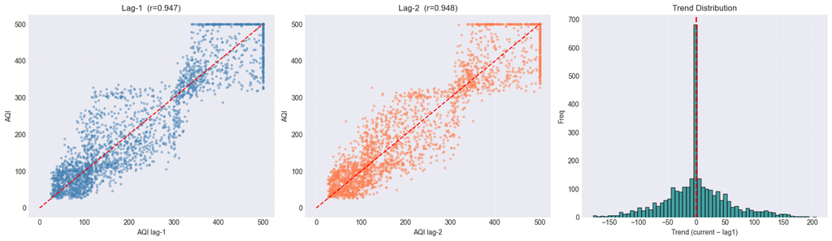

```python
fig, axes = plt.subplots(1, 3, figsize=(17, 5))

s = df.dropna(subset=['aqi_lag1','aqi_lag2']).sample(3000, random_state=42)

axes[0].scatter(s['aqi_lag1'], s['aqi'], s=8, alpha=0.4, color='steelblue')
axes[0].plot([0,500],[0,500], 'r--', lw=1.5)
axes[0].set(xlabel='AQI lag-1', ylabel='AQI', title=f'Lag-1  (r={df["aqi_lag1"].corr(df["aqi"]):.3f})')
axes[0].grid(alpha=0.3)

axes[1].scatter(s['aqi_lag2'], s['aqi'], s=8, alpha=0.4, color='coral')
axes[1].plot([0,500],[0,500], 'r--', lw=1.5)
axes[1].set(xlabel='AQI lag-2', ylabel='AQI', title=f'Lag-2  (r={df["aqi_lag2"].corr(df["aqi"]):.3f})')
axes[1].grid(alpha=0.3)

axes[2].hist(s['aqi_trend'].dropna(), bins=60, edgecolor='black', alpha=0.7, color='teal')
axes[2].axvline(0, color='red', ls='--', lw=2)
axes[2].set(xlabel='Trend (current − lag1)', ylabel='Freq', title='Trend Distribution')
axes[2].grid(alpha=0.3)

plt.tight_layout()
_save_and_show(fig, '14c_lags')
```

## 15. COVID-19 Flag & Train / Val / Test Split

India's national lockdown ran **≈ 25 Mar 2020 – 30 Sep 2021** (phased).  
Training on lockdown data without a flag teaches the model an unrepeatable artefact.

**Chronological split (no leakage):**

| Set | Period | Role |
| --- | --- | --- |
| Train | Jan 2020 – Dec 2023 | Fit |
| Validation | Jan 2024 – Dec 2024 | Tune hyper-params |
| Test | Jan 2025 – Dec 2025 | Final held-out eval |

```python
lockdown_start = pd.Timestamp('2020-03-25')
lockdown_end   = pd.Timestamp('2021-09-30')
df['is_lockdown'] = ((df['datetime']>=lockdown_start) & (df['datetime']<=lockdown_end)).astype(int)

lock_n   = df['is_lockdown'].sum()
lock_aqi = df.loc[df['is_lockdown']==1, 'aqi'].mean()
norm_aqi = df.loc[df['is_lockdown']==0, 'aqi'].mean()
print(f'Lockdown rows : {lock_n:,}  ({lock_n/len(df)*100:.1f}%)')
print(f'Mean AQI during lockdown  : {lock_aqi:.1f}')
print(f'Mean AQI outside lockdown : {norm_aqi:.1f}')
print(f'Difference: {lock_aqi-norm_aqi:+.1f}')
```

```
Lockdown rows : 50,968  (25.3%)
Mean AQI during lockdown  : 220.3
Mean AQI outside lockdown : 281.2
Difference: -61.0
```

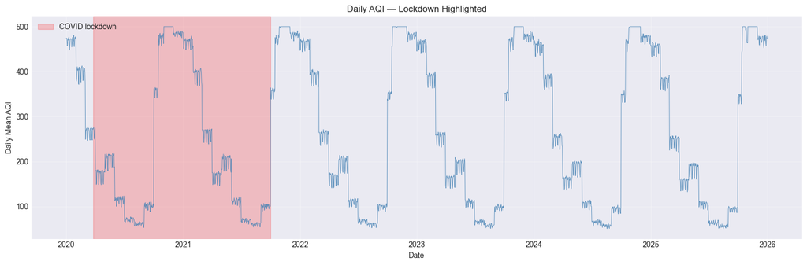

```python
daily = df.set_index('datetime')['aqi'].resample('D').mean()

fig, ax = plt.subplots(figsize=(15, 5))
ax.plot(daily.index, daily.values, lw=0.7, color='steelblue', alpha=0.8)
ax.axvspan(lockdown_start, lockdown_end, alpha=0.2, color='red', label='COVID lockdown')
ax.set(xlabel='Date', ylabel='Daily Mean AQI', title='Daily AQI — Lockdown Highlighted')
ax.legend(); ax.grid(alpha=0.3)
plt.tight_layout()
_save_and_show(fig, '15a_covid')
```

```python
train_end = pd.Timestamp('2023-12-31 23:59:59')
val_end   = pd.Timestamp('2024-12-31 23:59:59')

train = df[df['datetime'] <= train_end]
val   = df[(df['datetime'] > train_end) & (df['datetime'] <= val_end)]
test  = df[df['datetime'] > val_end]

print('Split:')
for name, split in [('Train',train),('Val',val),('Test',test)]:
    print(f'  {name:5s}: {len(split):>7,} rows | {split["datetime"].min().date()} → {split["datetime"].max().date()}')
print(f'\n  Train {len(train)/len(df)*100:.1f}% | Val {len(val)/len(df)*100:.1f}% | Test {len(test)/len(df)*100:.1f}%')
```

```
Split:
  Train: 134,412 rows | 2020-01-01 → 2023-12-31
  Val  :  33,672 rows | 2024-01-01 → 2024-12-31
  Test :  33,580 rows | 2025-01-01 → 2025-12-31

  Train 66.7% | Val 16.7% | Test 16.7%
```

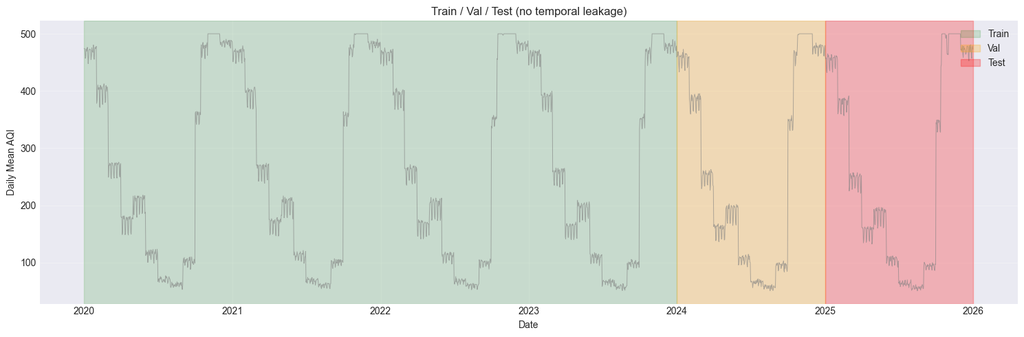

```python
fig, ax = plt.subplots(figsize=(15, 5))
ax.plot(daily.index, daily.values, lw=0.7, color='gray', alpha=0.6)
ax.axvspan(train['datetime'].min(), train['datetime'].max(), alpha=0.15, color='green',  label='Train')
ax.axvspan(val['datetime'].min(),   val['datetime'].max(),   alpha=0.25, color='orange', label='Val')
ax.axvspan(test['datetime'].min(),  test['datetime'].max(),  alpha=0.25, color='red',    label='Test')
ax.set(xlabel='Date', ylabel='Daily Mean AQI', title='Train / Val / Test (no temporal leakage)')
ax.legend(loc='upper right'); ax.grid(alpha=0.3)
plt.tight_layout()
_save_and_show(fig, '15b_split')
```

## 16. Stratified Baseline & RMSE by Bin

A single global RMSE hides where persistence actually fails.  
We slice **test-set** errors along three axes:

- **Hour transition** — identify the single hardest gap
- **Actual AQI category** — find which health bands need improvement
- **Season** — confirm the summer / winter failure modes

```python
# Persistence predictions on TEST only
tp = test.sort_values(['station','datetime']).copy()
tp['aqi_next']  = tp.groupby('station')['aqi'].shift(-1)
tp['hour_next'] = tp.groupby('station')['hour'].shift(-1)
tp = tp.dropna(subset=['aqi_next']).copy()

tp['pred']      = tp['aqi']          # persistence
tp['error']     = tp['aqi_next'] - tp['pred']
tp['abs_err']   = tp['error'].abs()
tp['transition']= tp['hour'].astype(int).astype(str) + ' → ' + tp['hour_next'].astype(int).astype(str)

def _rmse(s): return np.sqrt((s**2).mean())

overall_rmse = _rmse(tp['error'])
overall_mae  = tp['abs_err'].mean()
print(f'Test-set overall persistence:')
print(f'  RMSE = {overall_rmse:.2f}  |  MAE = {overall_mae:.2f}')
```

```
Test-set overall persistence:
  RMSE = 55.28  |  MAE = 38.01
```

```
RMSE by Transition:
              RMSE     MAE     N
transition
12 → 18     66.954  48.314  8395
6 → 12      59.607  41.886  8395
18 → 23     46.906  33.208  8395
23 → 6      44.542  28.587  8372
```

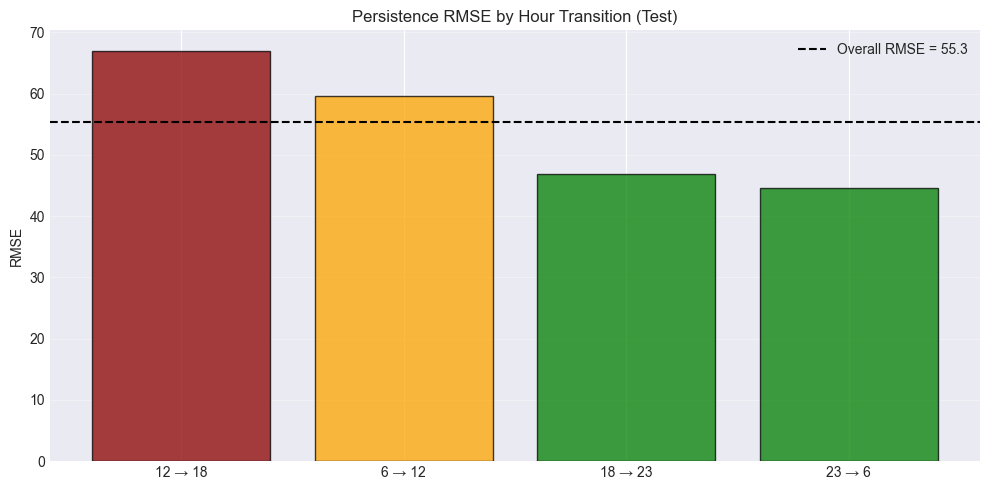

```
🎯 Hardest transition: 12 → 18  (RMSE = 66.95)
```

```python
tr_rmse = tp.groupby('transition')['error'].apply(_rmse).sort_values(ascending=False)
tr_mae  = tp.groupby('transition')['abs_err'].mean().reindex(tr_rmse.index)
tr_n    = tp.groupby('transition')['error'].count().reindex(tr_rmse.index)

print('RMSE by Transition:')
print(pd.DataFrame({'RMSE': tr_rmse, 'MAE': tr_mae, 'N': tr_n}))

fig, ax = plt.subplots(figsize=(10, 5))
clrs = ['darkred' if v>overall_rmse*1.15 else 'orange' if v>overall_rmse else 'green' for v in tr_rmse.values]
ax.bar(range(len(tr_rmse)), tr_rmse.values, color=clrs, alpha=0.75, edgecolor='black')
ax.axhline(overall_rmse, color='black', ls='--', lw=1.5, label=f'Overall RMSE = {overall_rmse:.1f}')
ax.set_xticks(range(len(tr_rmse))); ax.set_xticklabels(tr_rmse.index)
ax.set(ylabel='RMSE', title='Persistence RMSE by Hour Transition (Test)')
ax.legend(); ax.grid(alpha=0.3, axis='y')
plt.tight_layout()
_save_and_show(fig, '16a_rmse_transition')

print(f'\n🎯 Hardest transition: {tr_rmse.idxmax()}  (RMSE = {tr_rmse.max():.2f})')
```

```
RMSE by Actual Category:
                RMSE     MAE     N
actual_cat
Good          32.650  25.279  2645
Satisfactory  34.433  27.492  5833
Moderate      53.841  42.624  7538
Poor          78.101  64.288  2922
Very Poor     79.459  58.469  4901
Severe        47.782  25.974  9718
```

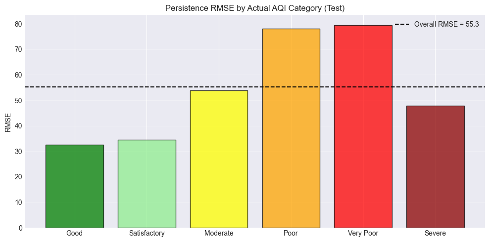

```
🎯 Hardest category: Very Poor  (RMSE = 79.46)
```

```python
def _aqi_cat(v):
    if v<=50:  return 'Good'
    if v<=100: return 'Satisfactory'
    if v<=200: return 'Moderate'
    if v<=300: return 'Poor'
    if v<=400: return 'Very Poor'
    return 'Severe'

tp['actual_cat'] = tp['aqi_next'].apply(_aqi_cat)

cat_order = ['Good','Satisfactory','Moderate','Poor','Very Poor','Severe']
cat_rmse  = tp.groupby('actual_cat')['error'].apply(_rmse).reindex(cat_order)
cat_mae   = tp.groupby('actual_cat')['abs_err'].mean().reindex(cat_order)
cat_n     = tp.groupby('actual_cat')['error'].count().reindex(cat_order)

print('RMSE by Actual Category:')
print(pd.DataFrame({'RMSE': cat_rmse, 'MAE': cat_mae, 'N': cat_n}))

fig, ax = plt.subplots(figsize=(10, 5))
c_clr = ['green','lightgreen','yellow','orange','red','darkred']
ax.bar(range(6), cat_rmse.values, color=c_clr, alpha=0.75, edgecolor='black')
ax.axhline(overall_rmse, color='black', ls='--', lw=1.5, label=f'Overall RMSE = {overall_rmse:.1f}')
ax.set_xticks(range(6)); ax.set_xticklabels(cat_order)
ax.set(ylabel='RMSE', title='Persistence RMSE by Actual AQI Category (Test)')
ax.legend(); ax.grid(alpha=0.3, axis='y')
plt.tight_layout()
_save_and_show(fig, '16b_rmse_category')

print(f'\n🎯 Hardest category: {cat_rmse.idxmax()}  (RMSE = {cat_rmse.max():.2f})')
```

```
RMSE by Season:
                RMSE     MAE        N
season
winter        59.563  37.136  11017.0
summer        72.269  58.198   8464.0
monsoon       36.455  28.025  11224.0
post-monsoon     NaN     NaN      NaN
```

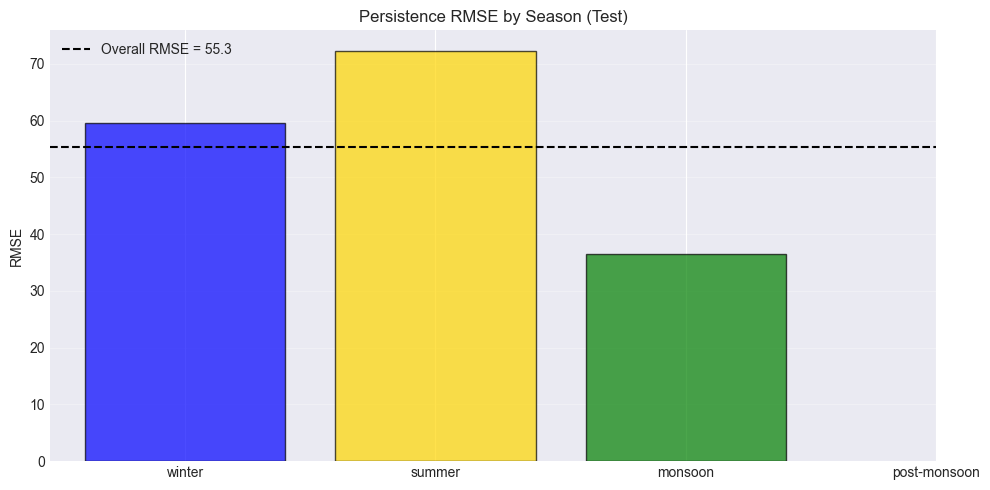

```
🎯 Hardest season: summer  (RMSE = 72.27)
```

```python
s_order  = ['winter','summer','monsoon','post-monsoon']
sea_rmse = tp.groupby('season')['error'].apply(_rmse).reindex(s_order)
sea_mae  = tp.groupby('season')['abs_err'].mean().reindex(s_order)
sea_n    = tp.groupby('season')['error'].count().reindex(s_order)

print('RMSE by Season:')
print(pd.DataFrame({'RMSE': sea_rmse, 'MAE': sea_mae, 'N': sea_n}))

fig, ax = plt.subplots(figsize=(10, 5))
s_clr = ['blue','gold','green','orange']
ax.bar(range(4), sea_rmse.values, color=s_clr, alpha=0.7, edgecolor='black')
ax.axhline(overall_rmse, color='black', ls='--', lw=1.5, label=f'Overall RMSE = {overall_rmse:.1f}')
ax.set_xticks(range(4)); ax.set_xticklabels(s_order)
ax.set(ylabel='RMSE', title='Persistence RMSE by Season (Test)')
ax.legend(); ax.grid(alpha=0.3, axis='y')
plt.tight_layout()
_save_and_show(fig, '16c_rmse_season')

print(f'\n🎯 Hardest season: {sea_rmse.idxmax()}  (RMSE = {sea_rmse.max():.2f})')
```

## 17. Summary & Export

```python
print('='*70)
print(' COMPREHENSIVE EDA SUMMARY')
print('='*70)

print('\n1  DATA')
print(f'   {len(df):,} rows | {df["station"].nunique()} stations | {df["city"].nunique()} cities')
print(f'   4 readings/day (h 6,12,18,23) → true horizon 5–7 h')
print(f'   Missing = 0  (⚠️  see forensics §12)')

print('\n2  TARGET')
print(f'   Mean={df["aqi"].mean():.1f} | Med={df["aqi"].median():.1f} | Range 25–500')
print(f'   {(df["aqi"]==500).mean()*100:.1f}% censored at 500')
print(f'   Persistence autocorr = {corr:.3f}')

print('\n3  TOP FEATURES (raw correlation)')
for f in correlations.head(3).index:
    print(f'   + {f}: {correlations[f]:.3f}')
for f in correlations.tail(3).index:
    print(f'   − {f}: {correlations[f]:.3f}')

print('\n4  FORENSICS FLAGS')
print(f'   Likely imputed : {df["is_imputed"].sum():,}  ({df["is_imputed"].mean()*100:.1f}%)')
print(f'   Censored (=500): {df["is_censored"].sum():,}  ({df["is_censored"].mean()*100:.1f}%)')
print(f'   COVID lockdown : {df["is_lockdown"].sum():,}  ({df["is_lockdown"].mean()*100:.1f}%)')

print('\n5  ENGINEERED FEATURES')
for f in ['ventilation_index','hours_since_last','hour_sin','hour_cos',
          'month_sin','month_cos','aqi_lag1','aqi_lag2','aqi_trend']:
    print(f'   ✓ {f}')

print('\n6  SPLIT')
print(f'   Train {len(train):>7,} | Val {len(val):>6,} | Test {len(test):>6,}')

print('\n7  STRATIFIED BASELINES (Test set)')
print(f'   Overall RMSE       : {overall_rmse:.2f}')
print(f'   Hardest transition : {tr_rmse.idxmax()}  ({tr_rmse.max():.2f})')
print(f'   Hardest category   : {cat_rmse.idxmax()}  ({cat_rmse.max():.2f})')
print(f'   Hardest season     : {sea_rmse.idxmax()}  ({sea_rmse.max():.2f})')

print('\n' + '='*70)
print(' All plots → plots/')
print('='*70)
```

```
======================================================================
 COMPREHENSIVE EDA SUMMARY
======================================================================

1  DATA
   201,664 rows | 23 stations | 5 cities
   4 readings/day (h 6,12,18,23) → true horizon 5–7 h
   Missing = 0  (⚠️  see forensics §12)

2  TARGET
   Mean=265.8 | Med=232.0 | Range 25–500
   22.5% censored at 500
   Persistence autocorr = 0.947

3  TOP FEATURES (raw correlation)
   + pm25: 0.801
   + pm10: 0.798
   + co: 0.777
   − wind_speed: -0.537
   − temperature: -0.734
   − visibility: -0.857

4  FORENSICS FLAGS
   Likely imputed : 5,775  (2.9%)
   Censored (=500): 45,355  (22.5%)
   COVID lockdown : 50,968  (25.3%)

5  ENGINEERED FEATURES
   ✓ ventilation_index
   ✓ hours_since_last
   ✓ hour_sin
   ✓ hour_cos
   ✓ month_sin
   ✓ month_cos
   ✓ aqi_lag1
   ✓ aqi_lag2
   ✓ aqi_trend

6  SPLIT
   Train 134,412 | Val 33,672 | Test 33,580

7  STRATIFIED BASELINES (Test set)
   Overall RMSE       : 55.28
   Hardest transition : 12 → 18  (66.95)
   Hardest category   : Very Poor  (79.46)
   Hardest season     : summer  (72.27)

======================================================================
 All plots → plots/
======================================================================
```

```python
# Export cleaned + engineered dataframe
keep = [
    'datetime','station','city','hour','month','season','day_of_week','is_weekend',
    'pm25','pm10','no2','so2','co','o3',
    'temperature','humidity','wind_speed','visibility','aqi','aqi_category',
    'is_imputed','is_censored','is_lockdown',
    'ventilation_index','hours_since_last',
    'hour_sin','hour_cos','month_sin','month_cos',
    'aqi_lag1','aqi_lag2','aqi_trend','gap_hours'
]
keep = [c for c in keep if c in df.columns]
df[keep].to_csv('delhi_aqi_engineered.csv', index=False)

print(f'✓ Exported {len(keep)} columns → delhi_aqi_engineered.csv')
print('  Ready for baseline & advanced ML pipelines.')

import glob
pngs = sorted(glob.glob('plots/*.png'))
print(f'\n📁 {len(pngs)} PNG plots saved:')
for p in pngs:
    print(f'   {p}')
```

```
✓ Exported 33 columns → delhi_aqi_engineered.csv
  Ready for baseline & advanced ML pipelines.

📁 19 PNG plots saved:
   plots\05_station_map.png
   plots\06_aqi_distribution.png
   plots\07_pollutants.png
   plots\08_weather.png
   plots\09_correlations.png
   plots\10a_daily_timeseries.png
   plots\10b_temporal_grid.png
   plots\11_spatial.png
   plots\12a_interpolation_scatter.png
   plots\12b_censorship_500wall.png
   plots\13_persistence.png
   plots\14a_ventilation.png
   plots\14b_cyclical.png
   plots\14c_lags.png
   plots\15a_covid.png
   plots\15b_split.png
   plots\16a_rmse_transition.png
   plots\16b_rmse_category.png
   plots\16c_rmse_season.png
```